# STAT/MATH 495: Problem Set 07

Jonathan Che

2017-10-24

Information on the competition can be found [here](https://www.kaggle.com/c/GiveMeSomeCredit/data).

# EDA

I first examine the distributions of the three chosen variables. Note that `DebtRatio` and `MonthlyIncome` exhibit strong power-law right skews, so I look at their logs (or log(x+1)) instead. Also, DebtRatio has a large number of values near 0. As such, only the histogram that excludes those values can capture the more delicate trends in the right tail of its distribution.

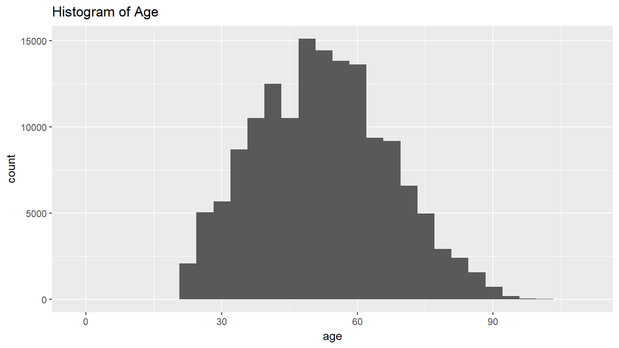

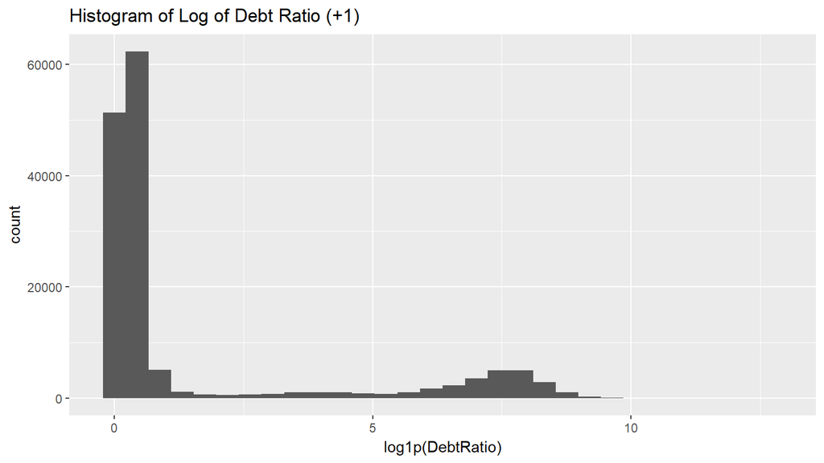

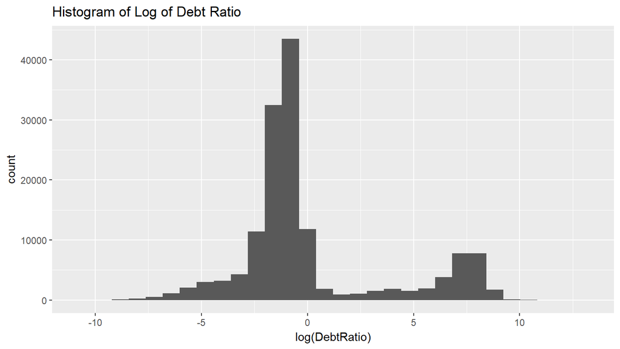

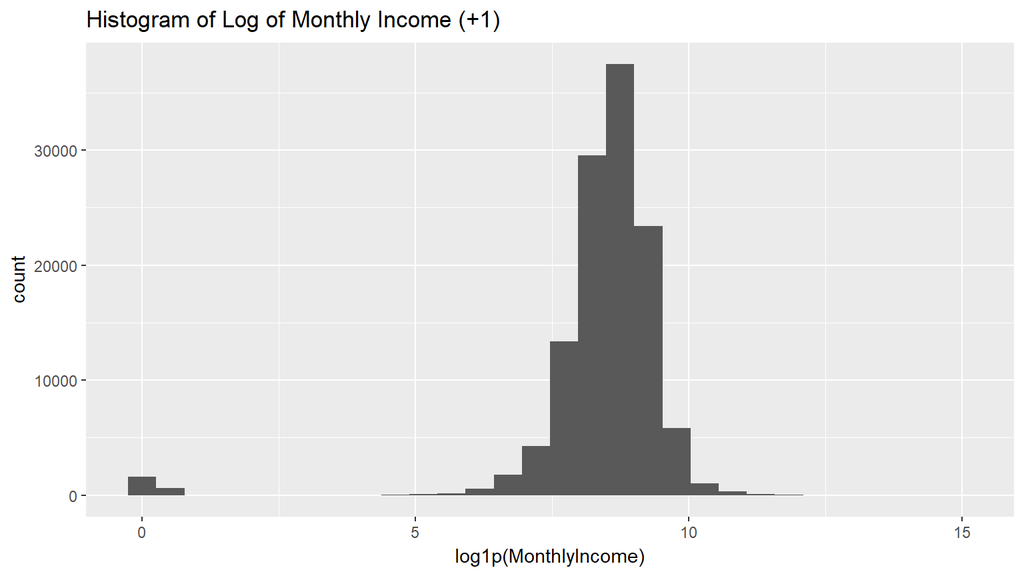

Now, I visualize each of the three variables’ relationships with `dlq`.

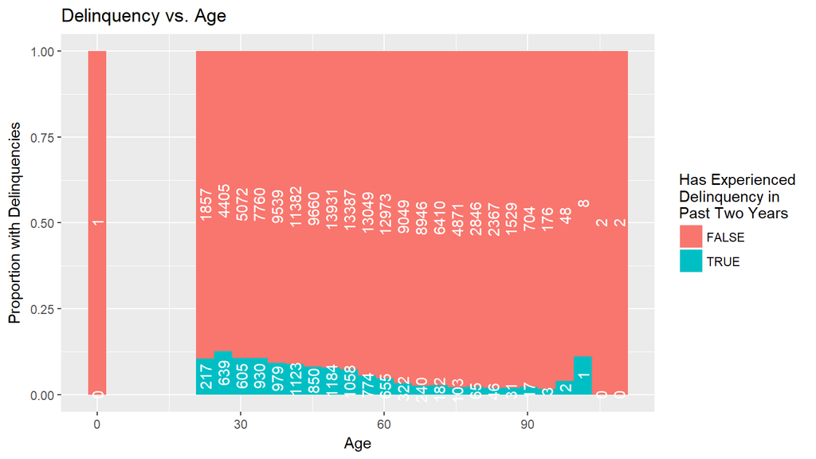

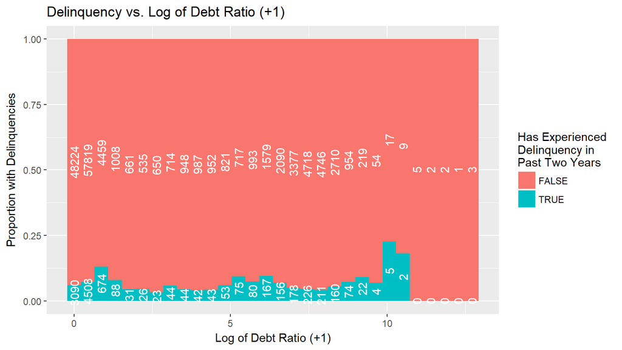

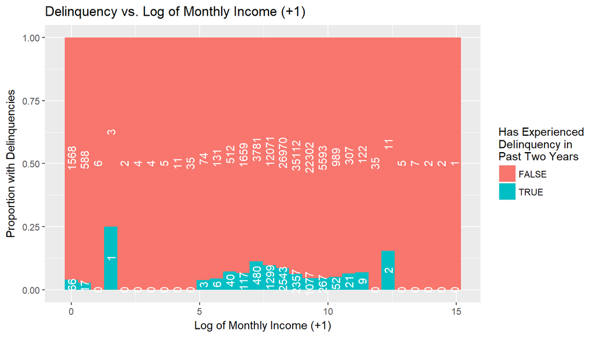

Of the three potential variables, `age` seems like it has the clearest and most intuitive trends for the proportion of individuals that have experienced delinquency in the past two years. While there are trends in the other two variables, the trends don’t seem as “linear” as the one in age. Since I will be using logistic regression, it will be simpler (and hopefully better) to use the information captured by a linear relationship rather than create categoricals and indicators to help a logistic regression capture the relationships of `dlq` with `DebtRatio` and `MonthlyIncome`.

# Build binary classifier

So, I train a logistic regression model on `age` and create my Kaggle submission.

```r
m <- glm(SeriousDlqin2yrs ~ age, data=train, family="binomial")

preds <- predict(m, test)
submission <- data.frame(test$Id, preds) %>%
  mutate(
    Id = test.Id,
    Probability = 1/(1+exp(-preds))) %>%   # Convert log odds to probabilities
  select(-test.Id, -preds)
write.csv(submission, "submission.csv", row.names=FALSE)
```

# ROC curve

Now I plot a ROC curve for the model I trained.

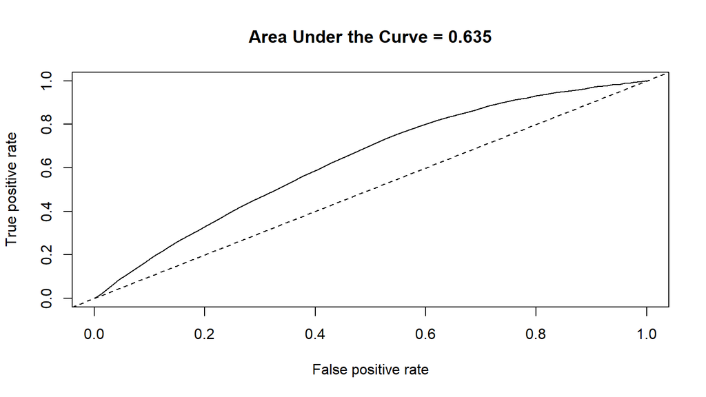

# ROC curve for random guessing

We can also see what the ROC curve would look like if we just randomly guessed instead of using logistic regression.

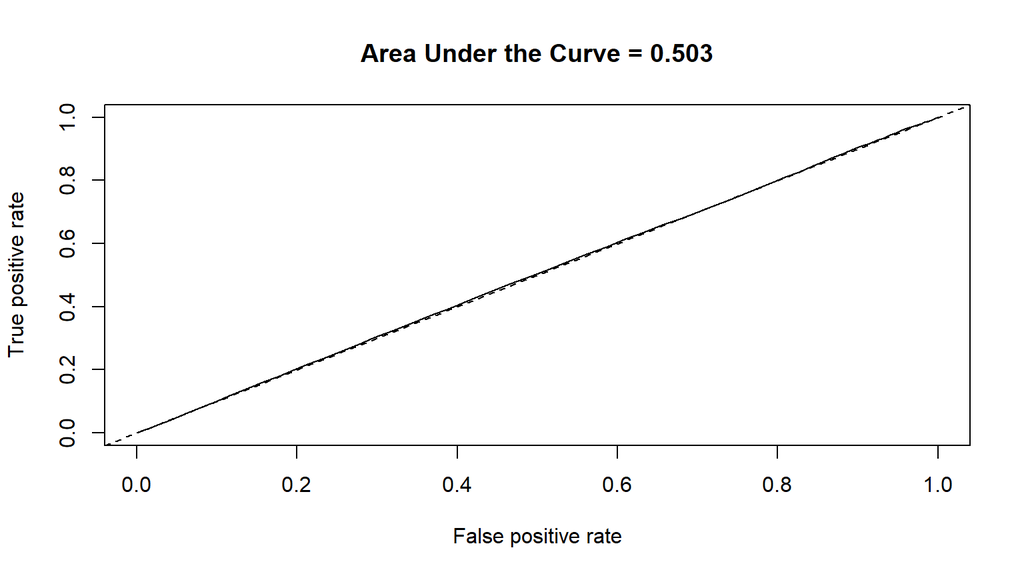